# FoRTE baseline

Alexey N. Shiklomanov

Jeff Atkins

Ben Bond-Lamberty

Christopher M. Gough

07 June, 2019

Abstract

# Introduction

**Instead, more reliable predictions can be obtained by using dynamic vegetation models that explicitly represent processes involved in forest growth and mortality.** Vegetation models fall broadly along the following spectrum of complexity. On one side are relatively simple **“Big leaf” models**—such as PNET, SiBCASA, and Biome-BGC —in which the vegetation at a particular location consists essentially of a single large “plant” whose characteristics are the (weighted) average of all the vegetation at that site. These models were designed originally to simulate the land surface boundary condition for atmospheric general circulation models, though similar models continue to be applied successfully to simulate biogeochemical processes in many ecosystem science contexts. On the other end of the spectrum are **“individual-based” models** (a.k.a. “gap models”), which explicitly simulate multiple indivduals competing for resources at a single site (Shugart et al. 2015). Examples of such models are LANDIS and UVAFME. Because these models can explicitly represent inter-specific differences in plant productivity, resource allocation, and stress tolerance (among others), as well as the competition that emerges out of these differences, they may be better able to represent changes in ecosystem-scale processes, especially in no-analog conditions (Purves and Pacala 2008). Moreover, these models’ **predictions of species composition and ecosystem structure are relevant outside of carbon cycle science**, particularly for forest management and wildlife conservation. However, these **benefits of individual-based models come at the cost of much higher data and computational requirements**, which effectively restrict their application to individual, well-studied sites.

A key challenge of vegetation modeling research over the last several decades has been the **development of approaches that capture the emergent biogeochemical and ecological outcomes of interactions between individual plants without the need for explicitly simulating each individual** (Purves and Pacala 2008). One such approach is the **“ecosystem demography” approach**, which uses a system of partial differential equations to simulate the emergent mean behavior of “cohorts” of individuals of similar composition, size, and age (Moorcroft et al. 2001). The original “Ecosystem Demography” (ED) model (Moorcroft et al. 2001) was enhanced by Medvigy et al. (2009) (as ED2) with fully-coupled leaf physiology, canopy radiative transfer, and micrometeorology, and each of these components have been further refined over the last decade (culminating in ED2.2; Longo et al. 2019b). Various versions of the ED model have been validated in boreal (Medvigy and Moorcroft 2011), temperate (Medvigy et al. 2009, Dietze et al. 2014, Raczka et al. 2018), and tropical biomes (Moorcroft et al. 2001, Longo et al. 2019a), and have been applied in:

**Vegetation model projections are inherently uncertain, and this uncertainty stems from several sources.** *Driver* uncertainty refers to uncertainty in data about processes that are essential to the system in question but are not represented by the model (e.g. weather and climate for vegetation models). *Initial condition* uncertainty arises from the fact that models have to start somewhere, and the exact conditions at the place and time simulations begin are uncertain. *Process* or *structural* uncertainty arises because vegetation models necessarily only represent a subset of all processes involved in plant biology, and that the process that are included can usually be represented in multiple different ways (i.e. which processes are included, and how they are represented). Finally, *parameter* uncertainty arises because of natural variability and imperfect calibration of the above process representations.

**Several recent studies have looked at parameter uncertainty in ED2.** Dietze et al. (2014) evaluated which ED2 parameters contributed the most to uncertainties in ED2 simulations of productivity across multiple biomes in North America at 1, 5, and 10 year time scales. They found that the parameters contributing the most to model uncertainty across all biomes were those related to growth respiration, mortality, stomatal conductance, and water uptake. However, they also found that despite some common patterns, parameter uncertainty varied with biome. More recently, a similar analysis evaluated parameter uncertainty over 100 year time scale at the Willow Creek Ameriflux site, and found that the most important parameters to model uncertainty were quantum efficiency of photosynthesis, leaf respiration, and soil-plant water transfer (Raczka et al. 2018). Another recent study assessed parameter uncertainty in ED2 as part of its overall goal of parameterizing the model for sagebrush (Pandit et al. 2018). They found that the most important parameters were specific leaf area, the maximum rate of carbon fixation (V<sub>cmax</sub>), slope of stomatal conductance, the fine-root to leaf carbon ratio, and the fine root turnover rate. Another study looked specifically at contributions to uncertainty from parameters related to canopy radiative transfer, and found that parameters related to both canopy structure and leaf optical properties had a large (>20%) impact on predictions of net primary productivity (Viskari et al. 2019). The variability in results across these studies demonstrates that parameter contributions to ED2 uncertainty are highly variable, and that additional parameter uncertainty studies are needed.

**The focus of this study is on the interaction between parametric and structural uncertainty in the ED2 model.** Driver uncertainty is outside the scope of this study, and initial condition uncertainty is minimized by our experimental design, which is conditioned on a specific initial condition (near bare ground). Our study is organized around the following guiding questions: (1) Which processes related to light utilization are most important to accurately modeling community succession and C cycle dynamics in temperate forests of the Upper Midwest? (2) What is the cost of considering these processes, in terms of additional parameteric uncertainty? (3) What are the relative contributions of parameteric uncertainty (data limitation) vs. structural uncertainty (theoretical limitation?)? To answer these questions, we ran ED2 ensemble simulationes with a factorial combination of submodels related to radiative transfer formulation (two-stream vs. multiple scatter), horizontal competition (finite canopy radius vs. complete shading), and trait plasticity (whether or not SLA and Vcmax vary with light level) We then used a sensitivity and variance decomposition analysis to evaluate the contribution of parameter uncertainty for each model configuration.

# Methods

## Site description

We performed this study at the University of Michigan Biological Station (Ameriflux site US-UMd, 45.5625$^{\circ}$, -84.6975$^{\circ}$), located in Northern Lower Michigan, USA. The area surrounding the research station is 87% well-drained upland forest and 13% wetland (Bergen and Dronova 2007); the focus of this study is on the former. The landscape geography of the UMBS upland forest is 20.4% moraine, 37.8% high outwash plain, 31.3% low outwash plain, 5.7% lake-margin terrace, 3.6% ice-contact, and 1.2% lowland glacial lake (Bergen and Dronova 2007). Most of the UMBS upland forest canopy is dominated by temperate deciduous early-successional species, most importantly *Populus grandidentata* (bigtooth aspen) and, to a lesser extent, *Betula papyrifera* (paper birch), with *Acer saccharum* (sugar maple), *Acer rubrum* (red maple), *Fagus grandifolia* (American beech), *Tilia americana* (basswood), *Betula alleghaniensis* (yellow birch), *Fraxinus americana* (white ash), *Tsuga canadensis* (eastern hemlock), *Quercus rubra* (northern red oak), *Pinus strobus* (white pine), and *Pinus resinosa* (red pine) existing in various fractions in the understory (and, in patches, in the canopy). This composition is a legacy of the site’s disturbance history: The site was intensively logged in the late 1800s and early 1900s, and experienced regularly recurring fires until the mid-1920s, at which point a regime of active fire suppression started that has persisted to the present day. As a result, the average stand age in 2013 was 95 years. The majority of the forest that is aspen-dominated is undergoing succession to “northern hardwood” (maple, beech, basswood, birch, ash, hemlock), “upland conifer” (red and white pine), or “northern red-oak” ecotypes (Bergen and Dronova 2007).

## Ecosystem Demography Model (version 2.2)

For this study, we used the Ecosystem Demography Model, version 2.2 (ED2). Below, we provide only a high-level description of key model features and focus in detail only on submodels and configurations specific to this study. A full description of the default configuration of the model is provided by Longo et al. (2019b).

ED2 represents both spatial and temporal variability hierarchically. The largest spatial unit is the “polygon”, within which all elements share the same meteorological forcings. Polygons are divided into multiple “sites”, each site with its own set of abiotic characteristics such as soil texture and topography. Sites are divided into discrete “patches” according to time since last disturbance. Finally, each patch is composed of an arbitrary (and dynamic) number of “cohorts”, representing the mean behavior of groups of plant individuals of similar size and composition. Temporal variability in ED2 is similarly hierarchical. Thermodynamics, including energy, water, and eddy (e.g. CO<sub>2</sub>) fluxes, are resolved on the order of seconds. Biophysics, including photosynthesis, respiration, and radiative transfer, and the evaluation of energy, water, and CO2 budgets, are resolved on the order of minutes. Phenology and plant carbon balance are evaluated daily. Cohort dynamics, including structural growth, mortality, and reproduction, are evaluated monthly. Finally, patch dynamics (e.g. annual disturbances) are evaluated annually. In this study, we consider only a single patch (and, therefore, a single site and polygon) starting from a “near bare ground” condition.

ED2 represents the carbon flux for each cohort as the net sum of contributions from turbulent mixing, leaf photosynthesis and respiration, (fine) root respiration, growth and maintenance respiration, and heterotrophic respiration. In addition, each cohort also has a virtual carbon balance that links fast processes like photosynthesis and respiration to slow processes like allocation (to growth, storage, and reproduction) and mortality.

The official ED2 source code is available at https://github.com/EDmodel/ED2, and the exact version used in this study (which includes minor revisions to accommodate the requirements of this study) can be obtained https://github.com/ashiklom/ED2/tree/b048950971e91699b78fc566df133caf977fda32.

## ED2 submodels

In this study, we ran a factorial combination of the following ED2 configurations: (1) two-stream vs. multiple-scatter canopy radiative transfer models; (2) infinite vs. finite crown area (a.k.a. complete vs. partial shading); and (3) static vs. light-plastic traits.

Both canopy radiative transfer models in ED2 resolve the full vertical radiation profile within a patch as a function of canopy structure (leaf and wood area indices, crown area, leaf angle distribution) and incident solar radiation. The two models differ in the mathematical approximations of the underlying differential radiative transfer equations.

- Two-stream model (ED default)
  - Same general approach as in CLM 4.5 (Oleson et al. 2013), but rather than solving for just two layers (sunlit and shaded), solve for each canopy layer.
  - Set up the two-stream equations for each layer as a linear system and solve the entire set of equations numerically
  - Similar to approaches used in other models: JULES (Mercado et al. 2007), ORCHIDEE-CAN (Naudts et al. 2015), CLM(SPA) (Bonan et al. 2014)
  - For details, see Supplements S9 and S10 in (Longo et al. 2019b).
- Multiple scatter model
  - Based on Zhao and Qualls (2005)

The crown area submodel in ED2 determines the nature of competition for light between cohorts. In the default configuration (“infinite crown area”, or “complete shading”), the leaf area of a cohort is distributed across the entire horizontal area of a patch. This means that taller cohorts always receive more incoming radiation than shorter cohorts, even when the height difference is small. Put another way, this means that there is no horizontal competition, only vertical. This has been shown to excessively suppress competition from sub-dominant individuals and result in unrealistically homogeneous canopies (Fisher et al. 2015). In the alternate configuration (“finite crown area”, or “partial shading”), canopies take up only a fraction of the available horizontal area, meaning that multiple cohorts of similar height can receive the same level of light. The horizontal area of crowns is determined by allometric equations from Dietze and Clark (2008).

The third submodel we evaluated was trait plasticity. In the default configuration, all cohorts of a given plant functional type will have the same parameters, regardless of environmental conditions. This ignores the globally-documented intraspecific trait variability as a function of light level (Niinemets 2010, Keenan and Niinemets 2016). In the alternate configuration, as light level decreases (trees become more shaded), specific leaf area increases and V<sub>cmax</sub> decreases, following empirical relationships from the tropics (Lloyd et al. 2010).

## ED2 parameters

The full list of parameters in ED2 is large, with over 100 parameters per plant functional type. A full sensitivity and uncertainty analysis across all of these parameters is outside the scope of this study. Instead, we selected a subset of parameters that were identified as important by previous ED2 sensitivity studies (Dietze et al. 2014, Raczka et al. 2018, Viskari et al. 2019).

Three parameters are related to leaf-level physiology: Following the enzyme-kinetic model of Farquhar et al. (1980), the rate of photosynthesis is the minimum of light-limited and enzyme-limited reactions. The former are controlled by the *quantum efficiency* parameter—maximum efficiency with which absorbed photosynthetically active radiation is converted to CO<sub>2</sub>. The latter are controlled by *V<sub>cmax</sub>*, the maximum rate of carbon fixation by Rubisco. The water demand of photosynthesis is controlled by the *stomatal slope*, the sensitivity of stomatal conductance of CO<sub>2</sub> as a function of CO<sub>2</sub> concentration and humidity at the leaf surface (Ball et al. 1987, Leuning 1995). Three more parameters correspond to the respiration rates of leaves, roots, and “growth maintenance”. Two more parameters control carbon allocation: One is the ratio of fine root to leaf biomass (`fineroot2leaf`, or `q`), and another is the ratio of “storage” carbon allocated to reproduction (`r_fract`). Three parameters control various aspects of adult tree mortality, namely the density-independent mortality rate (`mort3`), and the time scale (`mort1`) and critical carbon balance (`mort2`) of mortality from carbon starvation. An additional parameter controls seedling mortality. *Specific leaf area* (`SLA`) is used to convert leaf biomass to leaf area index, which in turn is used in a variety of calculations related to canopy radiative transfer and micrometeorology. Two additional parameters describe canopy structure in ways critical to the canopy radiative transfer: Canopy *clumping factor* describes how evenly leaf area is distributed in horizontal space (1 being perfectly evenly; 0 being a “black hole” where all leaves are concentrated in a single point); and leaf *orientation factor* describes the average distribution of leaf angles (-1 being perfectly vertical, 1 being perfectly horizontal, and 0 being random). Four parameters control leaf optical properties, namely the fractions of light reflected or transmitted in visible and near-infrared wavelengths (`leaf_(reflect|trans)_(vis|nir)`). Three other parameters:

- Fraction of litter carbon that enters the labile (fast) soil carbon pool (`f_labile`)
- Minimum plant height for reproduction (`minimum_height`)
- Soil-plant water conductance, or “water availability factor” (`water_conductance`)

Plant functional type-species mappings

| Plant functional type | Species |
| --- | --- |
| Early hardwood | *Betula papyrifera* |
|  | *Populus grandidentata* |
|  | *Populus tremuloides* |
| Mid hardwood | *Quercus rubra* |
|  | *Acer rubrum* |
|  | *Acer pensylvaticum* |
| Late hardwood | *Acer saccharum* |
|  | *Fagus grandifolia* |
| Pine | *Pinus strobus* |

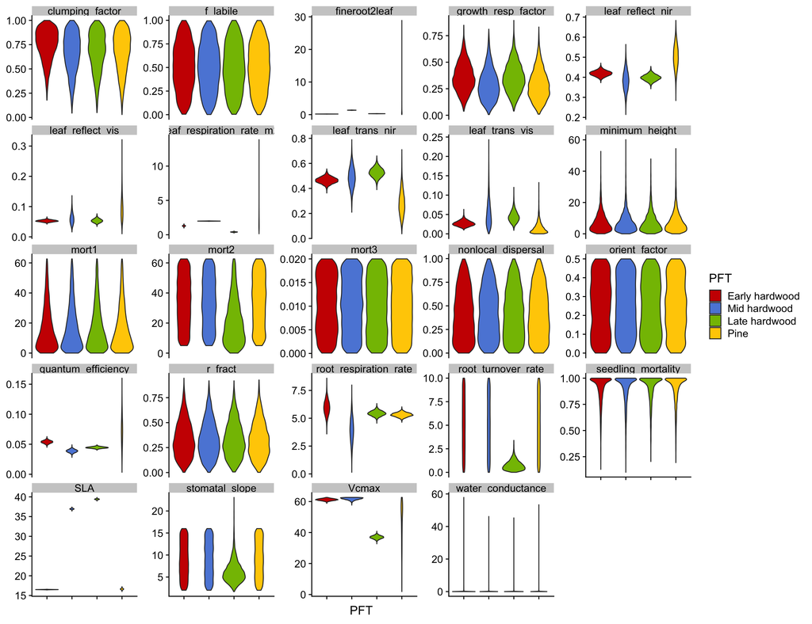

Input parameter distributions from PEcAn trait meta-analysis.

## Analysis of results

# Results

## Summary

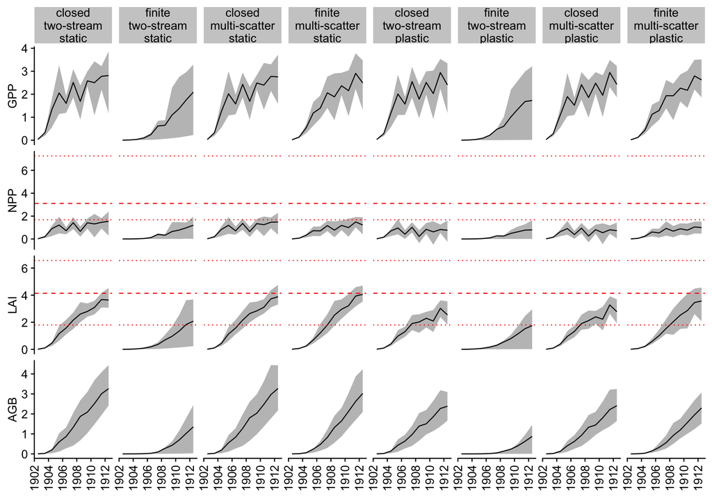

ED2 plot-level ensemble predictions of gross (GPP) and net (NPP) primary productivity, total leaf area index (LAI), and aboveground biomass (AGB) by model configuration. Red lines are mean (dashed) and min/max (dotted) values from Hardiman et al. (2013).

Take-away: Parameter uncertainty is as large as, or even larger, than structural uncertainty.

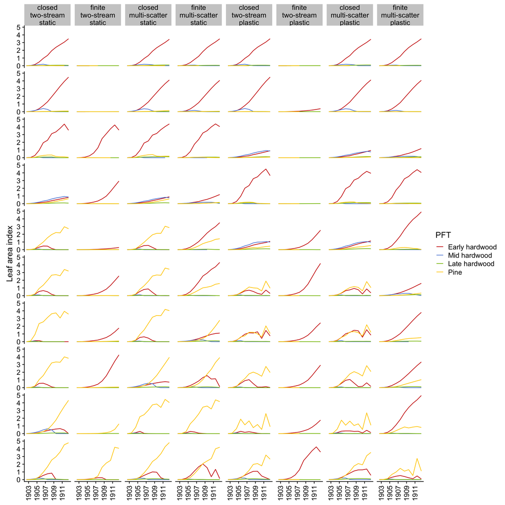

ED2 PFT-level predictions of leaf area index (LAI) by model configuration and parameterization.

Take-away: Different parameter combinations produce not just quantitatively different bulk ecosystem properties (e.g. NPP, total LAI), but also qualitatively different successional/ecological outcomes.

## Uncertainty analysis

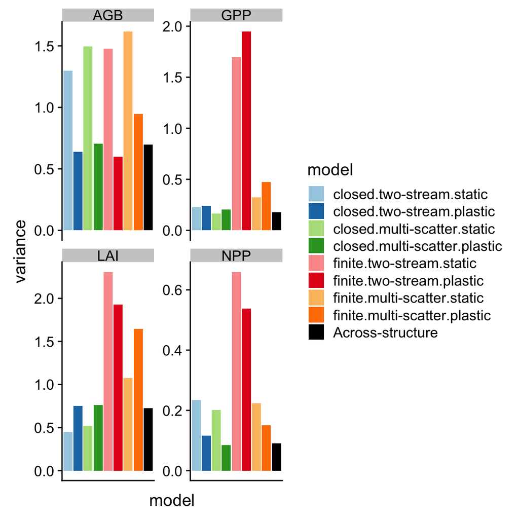

Comparison of parameteric uncertainty within ensembles (colored bars, colored by model type) and “structural” uncertainty (variance in ensemble means; black bar) by output variable. Output variables are expressed as growing season averages for all years after 1910.

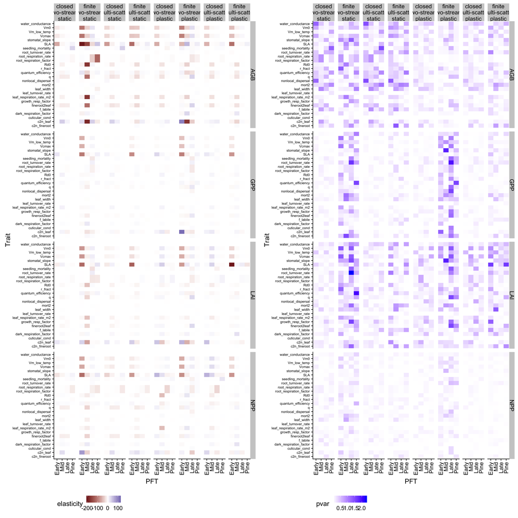

Take-away: Model parameter uncertainty is sensitive to model configuration. For example, turning on the finite canopy radius with the two-stream canopy RTM increases sensitivity across many parameters.

## Details about model structures

# Discussion

# Conclusions

# Acknowledgements

# References

Ball, J. T., I. E. Woodrow, and J. A. Berry. 1987. A model predicting stomatal conductance and its contribution to the control of photosynthesis under different environmental conditions. Progress in Photosynthesis Research:221–224.

Bazzaz, F. A. 1979. The physiological ecology of plant succession. Annual Review of Ecology and Systematics 10:351–371.

Bergen, K. M., and I. Dronova. 2007. Observing succession on aspen-dominated landscapes using a remote sensing-ecosystem approach. Landscape Ecology 22:1395–1410.

Bonan, G. B., M. Williams, R. A. Fisher, and K. W. Oleson. 2014. Modeling stomatal conductance in the earth system: Linking leaf water-use efficiency and water transport along the soil-plant-atmosphere continuum. Geoscientific Model Development 7:2193–2222.

De Kauwe, M. G., B. E. Medlyn, S. Zaehle, A. P. Walker, M. C. Dietze, T. Hickler, A. K. Jain, Y. Luo, W. J. Parton, I. C. Prentice, and et al. 2013. Forest water use and water use efficiency at elevated CO2: A model-data intercomparison at two contrasting temperate forest FACE sites. Global Change Biology 19:1759–1779.

Dietze, M. C., and J. S. Clark. 2008. Changing the gap dynamics paradigm: Vegetative regeneration control on forest response to disturbance. Ecological Monographs 78:331–347.

Dietze, M. C., S. P. Serbin, C. Davidson, A. R. Desai, X. Feng, R. Kelly, R. Kooper, D. LeBauer, J. Mantooth, K. McHenry, and et al. 2014. A quantitative assessment of a terrestrial biosphere model’s data needs across North American biomes. Journal of Geophysical Research: Biogeosciences 119:286–300.

Etheridge, D. M., L. P. Steele, R. L. Langefelds, R. J. Francey, J.-M. Marnola, and V. I. Morgan. 1998. Historical CO2 records from the Law Dome DE08, DE08-2, and DSS ice cores. In trends: A compendium of data on global change. Carbon Dioxide Information Analysis Center, Oak Ridge National Laboratory, U.S. Department of Energy, Oak Ridge, TN, USA.

Farquhar, G. D., S. von Caemmerer, and J. A. Berry. 1980. A biochemical model of photosynthetic CO2 assimilation in leaves of C3 species. Planta 149:78–90.

Fisher, R. A., C. D. Koven, W. R. L. Anderegg, B. O. Christoffersen, M. C. Dietze, C. E. Farrior, J. A. Holm, G. C. Hurtt, R. G. Knox, P. J. Lawrence, J. W. Lichstein, M. Longo, A. M. Matheny, D. Medvigy, H. C. Muller-Landau, T. L. Powell, S. P. Serbin, H. Sato, J. K. Shuman, B. Smith, A. T. Trugman, T. Viskari, H. Verbeeck, E. Weng, C. Xu, X. Xu, T. Zhang, and P. R. Moorcroft. 2017. Vegetation demographics in earth system models: A review of progress and priorities. Global Change Biology 24:35–54.

Fisher, R. A., S. Muszala, M. Verteinstein, P. Lawrence, C. Xu, N. G. McDowell, R. G. Knox, C. Koven, J. Holm, B. M. Rogers, and et al. 2015. Taking off the training wheels: The properties of a dynamic vegetation model without climate envelopes, CLM4.5(ED). Geoscientific Model Development 8:3593–3619.

Friedlingstein, P., P. Cox, R. Betts, L. Bopp, W. von Bloh, V. Brovkin, P. Cadule, S. Doney, M. Eby, I. Fung, and et al. 2006. Climate-carbon cycle feedback analysis: Results from the C4MIP model intercomparison. Journal of Climate 19:3337–3353.

Friedlingstein, P., M. Meinshausen, V. K. Arora, C. D. Jones, A. Anav, S. K. Liddicoat, and R. Knutti. 2014. Uncertainties in CMIP5 climate projections due to carbon cycle feedbacks. Journal of Climate 27:511–526.

Friedman, S. K., and P. B. Reich. 2005. Regional legacies of logging: Departure from presettlement forest conditions in northern Minnesota. Ecological Applications 15:726–744.

Gates, F. C. 1930. Aspen association in northern Lower Michigan. Botanical Gazette 90:233–259.

Gough, C. M., B. S. Hardiman, L. E. Nave, G. Bohrer, K. D. Maurer, C. S. Vogel, K. J. Nadelhoffer, and P. S. Curtis. 2013. Sustained carbon uptake and storage following moderate disturbance in a great lakes forest. Ecological Applications 23:1202–1215.

Gough, C. M., C. S. Vogel, B. Hardiman, and P. S. Curtis. 2010. Wood net primary production resilience in an unmanaged forest transitioning from early to middle succession. Forest Ecology and Management 260:36–41.

Gough, C. M., C. S. Vogel, H. P. Schmid, H.-B. Su, and P. S. Curtis. 2008. Multi-year convergence of biometric and meteorological estimates of forest carbon storage. Agricultural and Forest Meteorology 148:158–170.

Hurtt, G. C., R. Dubayah, J. Drake, P. R. Moorcroft, S. W. Pacala, J. B. Blair, and M. G. Fearon. 2004. Beyond potential vegetation: Combining lidar data and a height-structured model for carbon studies. Ecological Applications 14:873–883.

Kattge, J., S. Díaz, S. Lavorel, I. C. Prentice, P. Leadley, G. Bönisch, E. Garnier, M. Westoby, P. B. Reich, I. J. Wright, J. H. C. Cornelissen, C. Violle, S. P. Harrison, P. M. Van Bodegom, M. Reichstein, B. J. Enquist, N. A. Soudzilovskaia, D. D. Ackerly, M. Anand, O. Atkin, M. Bahn, T. R. Baker, D. Baldocchi, R. Bekker, C. C. Blanco, B. Blonder, W. J. Bond, R. Bradstock, D. E. Bunker, F. Casanoves, J. Cavender-Bares, J. Q. Chambers, F. S. Chapin III, J. Chave, D. Coomes, W. K. Cornwell, J. M. Craine, B. H. Dobrin, L. Duarte, W. Durka, J. Elser, G. Esser, M. Estiarte, W. F. Fagan, J. Fang, F. Fernández-Méndez, A. Fidelis, B. Finegan, O. Flores, H. Ford, D. Frank, G. T. Freschet, N. M. Fyllas, R. V. Gallagher, W. A. Green, A. G. Gutierrez, T. Hickler, S. I. Higgins, J. G. Hodgson, A. Jalili, S. Jansen, C. A. Joly, A. J. Kerkhoff, D. Kirkup, K. Kitajima, M. Kleyer, S. Klotz, J. M. H. Knops, K. Kramer, I. Kühn, H. Kurokawa, D. Laughlin, T. D. Lee, M. Leishman, F. Lens, T. Lenz, S. L. Lewis, J. Lloyd, J. Llusià, F. Louault, S. Ma, M. D. Mahecha, P. Manning, T. Massad, B. E. Medlyn, J. Messier, A. T. Moles, S. C. Müller, K. Nadrowski, S. Naeem, Ü. Niinemets, S. Nöllert, A. Nüske, R. Ogaya, J. Oleksyn, V. G. Onipchenko, Y. Onoda, J. Ordoñez, G. Overbeck, W. A. Ozinga, S. Patiño, S. Paula, J. G. Pausas, J. Peñuelas, O. L. Phillips, V. Pillar, H. Poorter, L. Poorter, P. Poschlod, A. Prinzing, R. Proulx, A. Rammig, S. Reinsch, B. Reu, L. Sack, B. Salgado-Negret, J. Sardans, S. Shiodera, B. Shipley, A. Siefert, E. Sosinski, J.-F. Soussana, E. Swaine, N. Swenson, K. Thompson, P. Thornton, M. Waldram, E. Weiher, M. White, S. White, S. J. Wright, B. Yguel, S. Zaehle, A. E. Zanne, and C. Wirth. 2011. TRY – a global database of plant traits. Global Change Biology 17:2905–2935.

Keenan, T. F., and Ü. Niinemets. 2016. Global leaf trait estimates biased due to plasticity in the shade. Nature Plants 3.

Kilburn, P. D. 1960. Effects of logging and fire on xerophytic forests in northern Michigan. Bulletin of the Torrey Botanical Club 87:402.

LeBauer, D., R. Kooper, P. Mulrooney, S. Rohde, D. Wang, S. P. Long, and M. C. Dietze. 2017. BETYdb: A yield, trait, and ecosystem service database applied to second-generation bioenergy feedstock production. GCB Bioenergy 10:61–71.

LeBauer, D. S., D. Wang, K. T. Richter, C. C. Davidson, and M. C. Dietze. 2013. Facilitating feedbacks between field measurements and ecosystem models. Ecological Monographs 83:133–154.

Leuning, R. 1995. A critical appraisal of a combined stomatal-photosynthesis model for C3 plants. Plant, Cell and Environment 18:339–355.

Lloyd, J., S. Patiño, R. Q. Paiva, G. B. Nardoto, C. A. Quesada, A. J. B. Santos, T. R. Baker, W. A. Brand, I. Hilke, H. Gielmann, and et al. 2010. Optimisation of photosynthetic carbon gain and within-canopy gradients of associated foliar traits for Amazon forest trees. Biogeosciences 7:1833–1859.

Longo, M., R. G. Knox, N. M. Levine, A. L. S. Swann, D. M. Medvigy, M. C. Dietze, Y. Kim, K. Zhang, D. Bonal, B. Burban, and et al. 2019a. The biophysics, ecology, and biogeochemistry of functionally diverse, vertically- and horizontally-heterogeneous ecosystems: The Ecosystem Demography model, version 2.2 - part 2: Model evaluation. Geoscientific Model Development Discussions:1–34.

Longo, M., R. G. Knox, D. M. Medvigy, N. M. Levine, M. C. Dietze, Y. Kim, A. L. S. Swann, K. Zhang, C. R. Rollinson, R. L. Bras, and et al. 2019b. The biophysics, ecology, and biogeochemistry of functionally diverse, vertically- and horizontally-heterogeneous ecosystems: The Ecosystem Demography model, version 2.2 - part 1: Model description. Geoscientific Model Development Discussions:1–53.

Medvigy, D., and P. R. Moorcroft. 2011. Predicting ecosystem dynamics at regional scales: An evaluation of a terrestrial biosphere model for the forests of northeastern North America. Philosophical Transactions of the Royal Society B: Biological Sciences 367:222–235.

Medvigy, D., S. C. Wofsy, J. W. Munger, D. Y. Hollinger, and P. R. Moorcroft. 2009. Mechanistic scaling of ecosystem function and dynamics in space and time: Ecosystem demography model version 2. Journal of Geophysical Research 114.

Mercado, L. M., C. Huntingford, J. H. C. Gash, P. M. Cox, and V. Jogireddy. 2007. Improving the representation of radiation interception and photosynthesis for climate model applications. Tellus B 59.

Miller, A. D., M. C. Dietze, E. H. DeLucia, and K. J. Anderson-Teixeira. 2015. Alteration of forest succession and carbon cycling under elevated CO2. Global Change Biology 22:351–363.

Moorcroft, P. R., G. C. Hurtt, and S. W. Pacala. 2001. A method for scaling vegetation dynamics: The ecosystem demography model (ed). Ecological Monographs 71:557–586.

Naudts, K., J. Ryder, M. J. McGrath, J. Otto, Y. Chen, A. Valade, V. Bellasen, G. Berhongaray, G. Bönisch, M. Campioli, and et al. 2015. A vertically discretised canopy description for ORCHIDEE (SVN r2290) and the modifications to the energy, water and carbon fluxes. Geoscientific Model Development 8:2035–2065.

Niinemets, Ü. 2010. A review of light interception in plant stands from leaf to canopy in different plant functional types and in species with varying shade tolerance. Ecological Research 25:693–714.

Oleson, K. W., D. M. Lawrence, G. B. Bonan, B. Drewniak, M. Huang, C. D. Koven, S. Levis, F. Li, W. J. Riley, Z. M. Subin, S. C. Swenson, P. Thornton, A. Bozbiyik, R. Fisher, C. L. Heald, E. Kluzek, J.-F. Lamarque, P. J. Lawrence, R. Leung, W. Lipscom, S. Muszala, D. M. Ricciuto, W. Sacks, Y. Sun, J. Tang, and Y. Zong-Liang. 2013. Technical description of version 4.5 of the Community Land Model (CLM). NCAR Earth System Laboratory Climate; Global Dynamics Division.

Pandit, K., H. Dashti, N. F. Glenn, A. N. Flores, K. C. Maguire, D. J. Shinneman, G. N. Flerchinger, and A. W. Fellows. 2018. Optimizing shrub parameters to estimate gross primary production of the sagebrush ecosystem using the Ecosystem Demography (EDv2.2) model. Geoscientific Model Development Discussions:1–23.

Purves, D., and S. Pacala. 2008. Predictive models of forest dynamics. Science 320:1452–1453.

Raczka, B., M. C. Dietze, S. P. Serbin, and K. J. Davis. 2018. What limits predictive certainty of long‐term carbon uptake? Journal of Geophysical Research: Biogeosciences 123:3570–3588.

Rogers, A., B. E. Medlyn, J. S. Dukes, G. Bonan, S. von Caemmerer, M. C. Dietze, J. Kattge, A. D. B. Leakey, L. M. Mercado, Ü. Niinemets, and et al. 2016. A roadmap for improving the representation of photosynthesis in earth system models. New Phytologist 213:22–42.

Rollinson, C. R., Y. Liu, A. Raiho, D. J. P. Moore, J. McLachlan, D. A. Bishop, A. Dye, J. H. Matthes, A. Hessl, T. Hickler, and et al. 2017. Emergent climate and CO2 sensitivities of net primary productivity in ecosystem models do not agree with empirical data in temperate forests of eastern North America. Global Change Biology 23:2755–2767.

Shugart, H. H., G. P. Asner, R. Fischer, A. Huth, N. Knapp, T. Le Toan, and J. K. Shuman. 2015. Computer and remote-sensing infrastructure to enhance large-scale testing of individual-based forest models. Frontiers in Ecology and the Environment 13:503–511.

Thoning, K. W., P. P. Tans, and W. D. Komhyr. 1989. Atmospheric carbon dioxide at Mauna Loa Observatory: 2. Analysis of the NOAA GMCC data, 1974-1985. Journal of Geophysical Research: Atmospheres 94:8549–8565.

Viskari, T., A. Shiklomanov, M. C. Dietze, and S. P. Serbin. 2019. The influence of canopy radiation parameter uncertainty on model projections of terrestrial carbon and energy cycling. bioRxiv.

Zhao, W., and R. J. Qualls. 2005. A multiple-layer canopy scattering model to simulate shortwave radiation distribution within a homogeneous plant canopy. Water Resources Research 41.

# Appendix 1: Submodel descriptions

## Radiative transfer: Definitions

- $\omega$ – Clumping factor
- $LAI$ – Leaf area index
- TAI – Total area index (leaf and woody area)
- $LAI_e$ / $TAI_e$ – “Effective” area indices (accounting for clumping)

## Two-stream RTM

## Multiple scatter RTM

$$LAI_e = \omega LAI$$

$$TAI_e = LAI_e + WAI$$

$$TAI_{l} = \frac{TAI_e}{CAI}$$

Leaf ($w_l$) and wood ($w_w$) weights:

$$w_l = \frac{LAI_e}{TAI_e}$$
$$w_w = 1 - w_l$$

Projected area, based on coefficients $\phi_1$ and $\phi_2$.

$$a_{proj} = \phi_1 + \phi_2 \mu$$

# Old outline

## Introduction

- Why we need models?
  - Forests are important, for C sequestration, other ecosystem services
  - Policy decisions related to forests depend on future projections
  - We need models to make future projections
- What kinds of models are out there?
  - Traditional: “Big leaf” models
    - Needed to be simple to run on old computers
    - Don’t need as much data
    - …but they fail to capture important processes, which matter not only for accurate predictions about C cycle, but also because they are processes we care about (habitat, forestry, tourism, etc.)!
  - Individual-based models
    - Much more detailed, but harder to run, and need much more data.
    - Trade-off between complexity and accuracy.
- Cohort-based models like ED2 as a middle ground?
  - Core ED concept (Moorcroft et al. 2001)
  - ED2 developments – (Medvigy et al. 2009, Medvigy and Moorcroft 2011)
  - Most recent version – (Longo et al. 2019b)
  - Validation/applications of the ED model:
    - (Rollinson et al. 2017) – ED2 paleoclimate
    - (Miller et al. 2015) – ED2 at Duke FACE
    - (De Kauwe et al. 2013) – ED2 at Duke and Oak Ridge FACE
    - (Longo et al. 2019a) – Model evaluation in Tropics
- How much complexity do we need to accurately model ecological dynamics?
  - Lots of existing work on parameteric uncertainty
    - (Dietze et al. 2014)
    - (Raczka et al. 2018)
    - (Pandit et al. 2018)
  - Less on structural uncertainty – i.e. not just what coefficients do we use, but what *equations*, and more generally, what *processes* do we even consider?
- What are the processes that drive succession of ecological communities?
  - Competition for light (Bazzaz 1979)
  - Others? Leaning towards omitting because factorial combination becomes too large.
    - Competition for water?
    - Competition for nutrients? (ED’s N model isn’t very good. Alternatives are being developed, but not in ED mainline yet.)
- Brief review of community/ecosystem ecology of the Upper Midwest
  - UMBS is a useful site for testing these theories because of its natural history.
  - Around 1900, mature forest dominated by white (*Pinus strobus*) and red pine (*Pinus resinosa*), hemlock (*Tsuga canadensis*), and sugar maple (*Acer saccharum*).
  - But, repeat harvest and burning between 1880 and 1920 (Kilburn 1960) led to replacement by early successional aspen (*Populus grandidentata* and *Populus tremuloides*), birch (*Betula papyrifera*), and cherry (*Prunus pensylvatica*) (**???**, Gates 1930, Friedman and Reich 2005, Bergen and Dronova 2007).
  - Such aspen-dominated secondary forests are sustained by background levels of disturbance, particularly fire (Gates 1930)
  - However, due to aggressive fire suppression in the US, these forests are now undergoing succession, primarily to mid/late-successional hardwood (typified by sugar maple and American beech, *Fagus grandifolia*) or upland conifer (typified by red and white pine) (Bergen and Dronova 2007).
  - The combination of stand-replacing disturbance ~100 years ago and suppressed disturbance since then makes this an ideal site for testing a vegetation model run from bare ground without having to prescribe disturbance.
- Guiding questions:
  - Which of these processes do we need to be able to accurately model what happens (“community succession and C cycle dynamics”) to Midwestern forests?
  - What is the cost of considering these processes, in terms of additional parameteric uncertainty?
  - What are the relative contributions of parameteric uncertainty (data limitation) vs. structural uncertainty (theoretical limitation?)?
- Study overview:
  - ED with factorial combination of submodels related to radiative transfer formulation (two-stream vs. multiple scatter), horizontal competition (finite canopy radius vs. complete shading), and trait plasticity (whether or not SLA and Vcmax vary with light level)
  - Ensemble analysis to look at parameter uncertainty

## Methods

### Site description

- Secondary successional forest – bigtooth aspen (*Populus grandidentata*), northern red oak (*Quercus rubra*), red maple (*Acer rubrum*), paper birch (*Betula papyrifera*), eastern white pine (*Pinus strobus*)
- Average age – 95 years (2013)
- NEP in UMBS tower is 1.58 MG C ha<sup>-1</sup> yr<sup>-1</sup> (0.80-1.98) (1999-2006), but with landscape variation (REF?)
- Heavily logged in late 1800s and early 1900s, disturbed by fire until 1923 (REF)
- Present day composition typical of upper Great Lakes region
- Previously, the site of the FASET experiment (Gough et al. 2008, 2013)
- UMBS is 87% upland and 13% wetland (Bergen and Dronova 2007). We focus on the upland ecosystem, which has the following characteristics (from Bergen and Dronova (2007)):
  - 20.4% moraine, 37.8% high outwash plain, 31.3% low outwash plain, 5.7% lake-margin terrace, 3.6% ice-contact, 1.2% lowland glacial lake
  - 60.9% aspen-dominated, 16.6% northern hardwood (*Acer saccharum*, *Acer rubrum*, *Fagus grandifolia*, *Tilia americana* (basswood), *Betula alleghaniensis* (yellow birch), *Fraxinus americana* (white ash), *Tsuga canadensis*), 13.3% upland conifer (*Pinus strobus*, *Pinus resinosa*)
  - 1.6% northern red oak (*Quercus rubra*)
  - 60.9% transitioning from aspen to next succession, of which: 55.8% to northern hardwood, 34.7% to upland conifer, 3.8% to northern red oak, 2.6% to northern red oak-red maple, 3.1% to upland conifer-northern hardwood

### PFT definitions

- **Early successional hardwood**
  - *Betula papyrifera* (white/paper birch)
  - *Populus grandidentata* (bigtooth aspen)
  - *Populus tremuloides* (trembling aspen)
- **Mid successional hardwood**
  - *Quercus rubra* (red oak)
  - *Acer rubrum* (red maple)
  - *Acer pensylvaticum* (striped maple)
- **Late successional hardwood**
  - *Acer saccharum* (sugar maple)
  - *Fagus grandifolia* (American beech)
- **Pine**
  - *Pinus strobus* (white pine)
- *Omitted candidates*
  - Early hardwood
    - *Prunus pensylvatica* (fire cherry)
  - Mid hardwood
    - *Betula alleghaniensis* (yellow birch)
    - *Tilia americana* (basswood)
    - *Fraxinus americana* (white ash)
  - Late hardwood
    - *Ostyra virginiana* (hop-hornbeam)
  - Pine
    - *Pinus resinosa* (red pine)

**Table**: Parameter descriptions. For additional information, see the [ED2 model wiki](https://github.com/EDmodel/ED2/wiki/PFT-parameters).

| ED Name | Description | unit_markdown | Raczka | Dietze | Ran |
| --- | --- | --- | --- | --- | --- |
| `mort1` | Time-scale at which low-carbon balance plants die | years<sup>-1</sup> | Carbon balance mortality | Mortality | no |
| `root_turnover_rate` | Temperature dependent rate of fine root loss | year<sup>-1</sup> | Root turnover | Root turnover | yes |
| `growth_resp_factor` | Fraction of daily C gain lost to growth respiration | unitless (0-1) | Growth respiration | Growth Resp | yes |
| `stomatal_slope` | Slope between *A* and stomatal conductance (Leuning) | unitless | Stomatal sensitivity | Stomatal Slope | yes |
| `fineroot2leaf (q)` | Ratio of fine root to leaf biomass | unitless (mass ratio) | Root/Leaf carbon | Leaf:Root | yes |
| `r_fract` | Fraction of C storage to seed reproduction | unitless | Recruitment carbon | Reproduction? | yes |
| `f_labile` | Fraction of litter that goes to labile (fast) C pool | unitless (0-1) | Labile carbon | NA | yes |
| `water_conductance` | “Water availability factor” | m<sup>-2</sup> a<sup>-1</sup> (kg C root)<sup>-1</sup> | Soil-plant water conductance | Water Cond | yes |
| `mort3` | Density-independent (background) mortality rate | year<sup>-1</sup> | Background mortality | NA | no |
| `SLA` | Specific leaf area | m<sup>2</sup> kg<sup>-1</sup> C | Specific leaf area | SLA | yes |
| `Rd0` | Leaf dark respiration at 15 °C | ??? | Leaf respiration* | Leaf Resp* | yes |
| `dark_respiration_factor` | Ratio of leaf respiration to Vcmax | ??? | Leaf respiration* | Leaf Resp* | yes |
| `quantum_efficiency` | Farquhar model parameter (TODO) | mol CO<sub>2</sub> (mol photons)<sup>-1</sup> | Quantum efficiency | Quantum Eff. | yes |
| `Vcmax (Vm0)` | Maximum rate of CO<sub>2</sub> carboxylation at 15 °C | μmol m<sup>-2</sup> s<sup>-1</sup> | Vcmax | Vcmax | yes |
| `root_respiration_rate (_factor)` | Root respiration rate at 15 °C | μmol CO<sub>2</sub> (kg fineroot)<sup>-1</sup> | Root respiration | NA | yes |
| `minimum_height` | Minimum height for plant reproduction | m | Minimum height | NA | no |
| `leaf_reflect_vis` | Leaf reflectance in visible range (400-700 nm) | unitless (0-1) | NA | NA | no |
| `leaf_reflect_nir` | Leaf reflectance in NIR range (700-2500 nm) | unitless (0-1) | NA | NA | no |
| `leaf_trans_vis` | Leaf transmittance in visible range (400-700 nm) | unitless (0-1) | NA | NA | no |
| `leaf_trans_nir` | Leaf transmittance in NIR range (700-2500 nm) | unitless (0-1) | NA | NA | no |
| `c2n_fineroot` | C:N ratio in fine roots | unitless (mass ratio) | NA | NA | yes |
| `c2n_leaf` | C:N ratio in leaves | unitless (mass ratio) | NA | NA | yes |
| `leaf_turnover_rate` | Temperature dependent rate of leaf loss (conifer only) | year<sup>-1</sup> | NA | NA | yes |
| `leaf_width` | Mean leaf width (for boundary layer conductance) | m | NA | NA | yes |
| `mort2` | C balance ratio at which mortality rapidly increases | unitless (mass ratio) | NA | NA | yes |
| `nonlocal_dispersal` | “Proportion of dispersal that is global” | unitless (0-1) | NA | NA | yes |
| `seedling_mortality` | Proportion of seed that dies and goes to litter pool | unitless (0-1) | NA | NA | yes |
| `Vm_low_temp` | Minimum temperature for photosynthesis | °C | NA | NA | yes |

### Colophon

The current Git commit details are:

```
#> Local:    master /Users/shik544/Box Sync/Projects/forte_project/fortebaseline
#> Remote:   master @ origin (git@github.com:ashiklom/fortebaseline.git)
#> Head:     [2fe3685] 2019-06-07: First draft of text on submodels
```